# Coursework Report

*N* removed NAs: 2

*N* removed typo: 1

*N* removed <18: 21

*N* total clean: 126

| Group | *N* | *M*<sub>age</sub> | *M*<sub>rating</sub> |
| --- | --- | --- | --- |
| Control | 64 | 20.9 | 6.59 |
| Experim | 62 | 20.8 | 5.61 |

**Main analysis results**

*t*(124) = 7.05, *p* < .001

[interactive chart not shown]

[figure not shown]

[interactive chart not shown]

# Coursework Report

Analysing Data, Spring 2020

# Methods

## Participants

The conceptual hypothesis of this study is: Does colour influence attractiveness. The null hypothesis of this study is that there will be no significant difference between the colours when influencing attractiveness. I will use am independent *T*-test to measure the results.

Participants were shown an identical picture of an attractive young man. We operationalised the independent variable by having the picture in either a white frame or a red frame. The control condition is the white frame and the experimental condition is the red frame.

The dependent measures were operationalised through three likert scale questions where the answers were a rating between 1-9 where 1 was low and 9 was high. The questions were as follows:

1. How attractive do you think this person is?
2. How pleasant is this person to look at?
3. If I were to meet the person in the picture face to face, I would think he is attractive.

The operational hypothesis of this study is that participants rating the figure in the red frame will score higher ratings of attraction on the likert scale.

# Results

We investigated whether, as predicted, people would rate the image of a person more attractive dependent on the colour condition of the frame that the picture was in using an independent *t*-test. This test showed that the means in the two conditions were significantly different (*M*<sub>diff</sub> = 0.979, 95% CI [0.71, 1.26]) and there was a significant difference between the groups rating of attraction (*t*(124) = 7.05, p <.001). p<.001 which gives evidence that the null hypothesis should be rejected, as well as this the t value varies greatly from the 0, indicating a significant effect due to the independent variable. The table below shows the mean composite score for ratings of attraction in the two groups. The composite score was calculated by adding the 3 scores of attraction and dividing the answer by 3.

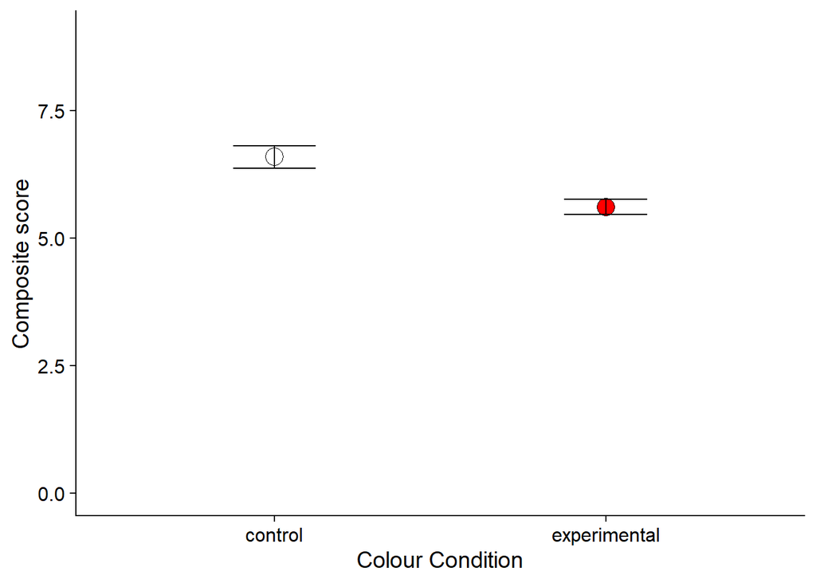

Below is the numerical statstical breakdown of the composite scores:

Table 2 *Descriptive statistics of Composite Scores

| Condition | N* | % | *M*<sub>Score</sub> | *SD*<sub>Score</sub> |
| --- | --- | --- | --- | --- |
| control | 64 | 50.8 | 6.59 | 0.89 |
| experimental | 62 | 49.2 | 5.61 | 0.65 |

The mean is statistically significantly higher in the control group compared to the experimental group. The standard error of each condition do not overlap providing more evidence for the significance of the result. However, the standard deviation of the two conditions do overlap but this just shows that in some cases the variance in results is similar but it is not statistically significant.

# Discussion

This study has shown that a white frame will provide significantly higher ratings of attraction compared to a red frame. This supports the conceptual hypothesis that colour will have an implication on attraction ratings, but it does not support the operational hypothesis and prediction that a red frame will score higher. The statistical results detail that there is a significant difference between the composite score of attraction in the control group and the experimental group whereby people rate the control group (white frame) higher.

Comparing my results to other studies allowed valuable insight into this field. My results indicated that a white frame was statistically significantly higher than a red frame, this is compared to Elliot et al who performed a similar study using a photo of a man in a red and white frame and using a 9-point likert scale rating of perceived attraction. Elliot et al found that ‘Participants in the red condition, compared to those in the white condition, rated the target man as more attractive’. Now this is contradictory to my results, however, Elliot did not record the gender of participants and this may be significant to the rating levels. Elliot’s second experiment investigated the effect of sex on the perceived attraction scale of a red and white background. Elliot found that ‘women in the red condition rated the target man as more attractive than did women in the white condition, whereas no colour difference was observed by men.’ This is significant to my results as it provides evidence that men do not rate attraction higher in a red condition. In my experiment there is no record of gender so there is no way to identify how many men or women were in my study. There perhaps could be a majority of men in the red condition which led to a lower composite score than expected, explaining the unusual result. It would improve my study in the future to record gender and perhaps even provide an equal split of gender between the two conditions as this may be another variable that needs to be discussed in this field.

A weakness in Elliot et al’s original study is that only ‘twenty-one female undergraduates in the United states participated ‘and this is a very small sample size and unrepresentative of the population, as as this no men took part. This is compared to my study that had 6 times the volume of participants and further comparing it to Lynn, Giebelhausen, Garcia and Patumanon (2016). They performed an online survey of 1,075 participants, comparing tipping rates to waitresses in either red, black, white or blue shirts. They found that there was ’no significant difference found between red and white shirts’, further supporting the theory that men aren’t susceptible to the red condition which may explain why my results differ from Elliot et al as we may have men in our study, explaining why the red condition was considerable lower. As well as this Giebelhausen used a larger sample size for more reliable, reproducible and ecologically valid results.

Another explanation for the result of my study is that we don’t take into context the individual differences in attraction in relation to long term mating and short term. Red and white both serve as signalling functions. Aslam (2006), Grieve (1991), Hutchings (2004), Monger (2004) and Phillip (2006) all argue that ‘in several societies, white symbolizes chastity, purity, high virtues and innocence.’ It is also argued that when seeking a long-term mate, ‘an important trait for males to consider for a woman would be premarital chastity and sexual fidelity, given the problem of paternity uncertainty (1989, 2003; Buss and Schmidt 1993)’. These important traits in a long-term mate are signalled by the colour white. So, participants who are seeking a long-term mate may rate the white condition more attractive than the red condition. This then explains the experiments’ results as they could be due to the individual difference of the participants goals and desires of future life, with those seeking a long term relationship rating white higher and those seeking a casual relationship rating white lower and red higher. This is due to red being ‘commonly associated with lust, love, sexuality and passion (Elliot and Maier, 2012)’.

This study was useful because it helped identify results for young adults in this field with mean ages of around 21. As well as this the sample size was moderate which allowed for more accurate and representative results compared to the sample population. However, this study had many limitations. There was no record of gender so we cannot identify differences due to gender. Future studies should record the gender of participants so they can identify gender differences in the rating scales and then perhaps using single gender studies in order to control more extraneous influences on the study. As highlighted earlier the result could be explained due to individual participant needs for a relationship as well as their goals and motivations for the future. A way that this study could be more useful, in terms of explaining results, would be a questionnaire based on the participants goals for future relationships. Questions such as ‘are you looking for a casual relationship’ could really give an insight into why people may find red or white more attractive. Another positive for this study is that it is easily stadardised using the same image and the same frame and can be easily reproduced. This results in high internal validity and reliable and reproducible results.

The overall conclusion from this study is that participants rated the image of a young man more attractive with a white frame than a red frame. It was statistically significant to the p < .001 level. The main implication of this study is that perhaps underlying individual differences of relationship goals have a greater impact on attraction rating than we first thought. This is shown by white signalling long term mating characteristics and red signalling short term characteristics. The next steps will be to repeat the study in the same format but to record gender and create a quiz with a critical question for what the participant is looking for in a relationship, perhaps another 1-9 likert scale with the question “what level of commitment are you looking for?”, with 1 being none at all and 9 being marriage.

# References

Elliot, A.J., Niesta Kayser, D., Greitemeyer, T., Lichtenfield, S., Gramzow, R. H., Maier, M.A., & Liu, H. (2010). Red, Rank, and Romance in Woman Viewing Men. *Journal of Experimental Psychology: General, 139*(3), 403.

Elliot, A.J., Niesta Kayser, D., Greitemeyer, T., Lichtenfield, S., Gramzow, R. H., Maier, M.A., & Liu, H. (2010). Red, Rank, and Romance in Woman Viewing Men. *Journal of Experimental Psychology: General, 139*(3), 404.

Elliot, A.J., Niesta Kayser, D., Greitemeyer, T., Lichtenfield, S., Gramzow, R. H., Maier, M.A., & Liu, H. (2010). Red, Rank, and Romance in Woman Viewing Men. *Journal of Experimental Psychology: General, 139*(3), 403.

Lynn, M., Giebelhausen, M., Garcia, S., Li, Y., Patumanon, I.(2016) Clothing Colour and Tipping: An attempted replication and extension. *Journal of Hospitality & Tourism Research: 40* 516-524.

Peperkorn, L., Roberts, C., Collet, T.(2016) Revisiting the Red Effect… Attractiveness and sexual Receptivity: No effect Of The Colour Red On Human Mate Preferences.[online] *SAGE Journals. available at: https://journals.sagepub.com/doi/full/10.1177/1474704916673841* [accessed 28th April 2020].

Peperkorn, L., Roberts, C., Collet, T.(2016) Revisiting the Red Effect… Attractiveness and sexual Receptivity: No effect Of The Colour Red On Human Mate Preferences.[online] *SAGE Journals. available at: https://journals.sagepub.com/doi/full/10.1177/1474704916673841* [accessed 28th April 2020].

Peperkorn, L., Roberts, C., Collet, T.(2016) Revisiting the Red Effect… Attractiveness and sexual Receptivity: No effect Of The Colour Red On Human Mate Preferences.[online] *SAGE Journals. available at: https://journals.sagepub.com/doi/full/10.1177/1474704916673841* [accessed 28th April 2020].